# R_Project_1

2025-09-22

# Анализ данных сервиса проката велосипедов

Сервисы проката велосипедов и самокатов продолжают набирать популярность благодаря своему удобству и скорости. Однако, они довольно сильно зависят от погодных условий. В нашем распоряжении есть дневные данные за 2011-2012 годы по поездкам на велосипедах в Вашингтоне. Данный проект направлен на исследование влияния погодных условий и других факторов на количество арендованных велосипедов.

## Обзор и подготовка данных

Для начала загрузим исходный датафрейм и изучим его содержимое:

```r
#Загружаем таблицу
data <- read.csv("day.csv", header = T)
str(data)
```

```
## 'data.frame':    731 obs. of  16 variables:
##  $ instant   : int  1 2 3 4 5 6 7 8 9 10 ...
##  $ dteday    : chr  "2011-01-01" "2011-01-02" "2011-01-03" "2011-01-04" ...
##  $ season    : int  1 1 1 1 1 1 1 1 1 1 ...
##  $ yr        : int  0 0 0 0 0 0 0 0 0 0 ...
##  $ mnth      : int  1 1 1 1 1 1 1 1 1 1 ...
##  $ holiday   : int  0 0 0 0 0 0 0 0 0 0 ...
##  $ weekday   : int  6 0 1 2 3 4 5 6 0 1 ...
##  $ workingday: int  0 0 1 1 1 1 1 0 0 1 ...
##  $ weathersit: int  2 2 1 1 1 1 2 2 1 1 ...
##  $ temp      : num  0.344 0.363 NA 0.2 0.227 ...
##  $ atemp     : num  0.364 0.354 0.189 0.212 0.229 ...
##  $ hum       : num  0.806 0.696 0.437 0.59 0.437 ...
##  $ windspeed : num  0.16 0.249 0.248 0.16 0.187 ...
##  $ casual    : int  331 131 120 108 82 88 148 68 54 41 ...
##  $ registered: int  654 670 1229 1454 1518 1518 1362 891 768 1280 ...
##  $ cnt       : int  985 801 1349 1562 1600 1606 1510 959 822 1321 ...
```

Мы имеем следующие переменные:

1. `instant`: id наблюдения
2. `dteday`: дата - season: время года - категориальная переменная
3. `yr`, `mnth`: год и месяц - категориальные переменные
4. `holiday`: наличие праздника в этот день - категориальная переменная
5. `weekday`: день недели - категориальная переменная
6. `workingday`: рабочий день или выходной - категориальная переменная
7. `weathersit`: погода - категориальная переменная
8. `temp`, `atemp`: реальная нормированная температура и субъективная нормированная оценка температуры - количественные переменные
9. `hum`, `windspeed`: нормированные влажность и скорость ветра - количественные переменные
10. `casual`: число случайных клиентов сервиса - количественная переменная
11. `registered`: число зарегистрированных клиентов сервиса - количественная переменная
12. `cnt`: сумма casual и registered - количественная переменная переменная

Функция str() показала, что далеко не все переменные были распознаны правильно при считывании таблицы, многие категориальные переменные указаны, как целочисленные). Перейдем к подготовке данных: разберемся с отсутствующими и выпадающими значениями, а также присвоим правильные типы данных столбцам таблицы.

### Отсутствующие значения

Подсчитаем количество отсутствующих значений в колонках

```r
sapply(data, FUN = function(x) {
  table(is.na(x))[2]
})
```

```
##      instant.NA       dteday.NA       season.NA           yr.NA         mnth.NA
##              NA              NA              NA              NA              NA
##      holiday.NA      weekday.NA   workingday.NA   weathersit.NA       temp.TRUE
##              NA              NA              NA              NA               2
##        atemp.NA        hum.TRUE  windspeed.TRUE       casual.NA registered.TRUE
##              NA               5               1              NA               1
##          cnt.NA
##              NA
```

NA есть в столбцах `temp`, `hum`, `windspeed` и `registered`. Всего отсутствующих значений 9, их удаление в масштабе набора из 700+ наблюдений едва ли повлияет на результаты анализа. Удалим эти наблюдения:

```r
data_wo_na <- na.omit(data)
```

### Установка типов данных

Посмотрим на уникальные значения категориальных переменных.

```r
sapply(data_wo_na[c(3:9)], FUN = function(x) {
  unique(x)
})
```

```
## $season
## [1] 1 2 3 4
##
## $yr
## [1] 0 1
##
## $mnth
##  [1]  1  2  3  4  5  6  7  8  9 10 11 12
##
## $holiday
## [1] 0 1
##
## $weekday
## [1] 6 0 2 3 4 5 1
##
## $workingday
## [1] 0 1
##
## $weathersit
## [1] 2 1 3
```

Как мы видим, число уникальных значений для каждой категориальной переменной совпадает с ожидаемым числом уровней. Нет необходимости работать с опечатками, можно задавать всем категориальным переменным тип factor.

```r
fac_data_wo_na <- data_wo_na %>%
  mutate(across(where(is.integer) & !c('instant', 'casual', 'registered', 'cnt'), as.factor))

str(fac_data_wo_na)
```

```
## 'data.frame':    722 obs. of  16 variables:
##  $ instant   : int  1 2 4 5 6 7 8 9 10 11 ...
##  $ dteday    : chr  "2011-01-01" "2011-01-02" "2011-01-04" "2011-01-05" ...
##  $ season    : Factor w/ 4 levels "1","2","3","4": 1 1 1 1 1 1 1 1 1 1 ...
##  $ yr        : Factor w/ 2 levels "0","1": 1 1 1 1 1 1 1 1 1 1 ...
##  $ mnth      : Factor w/ 12 levels "1","2","3","4",..: 1 1 1 1 1 1 1 1 1 1 ...
##  $ holiday   : Factor w/ 2 levels "0","1": 1 1 1 1 1 1 1 1 1 1 ...
##  $ weekday   : Factor w/ 7 levels "0","1","2","3",..: 7 1 3 4 5 6 7 1 2 3 ...
##  $ workingday: Factor w/ 2 levels "0","1": 1 1 2 2 2 2 1 1 2 2 ...
##  $ weathersit: Factor w/ 3 levels "1","2","3": 2 2 1 1 1 2 2 1 1 2 ...
##  $ temp      : num  0.344 0.363 0.2 0.227 0.204 ...
##  $ atemp     : num  0.364 0.354 0.212 0.229 0.233 ...
##  $ hum       : num  0.806 0.696 0.59 0.437 0.518 ...
##  $ windspeed : num  0.1604 0.2485 0.1603 0.1869 0.0896 ...
##  $ casual    : int  331 131 108 82 88 148 68 54 41 43 ...
##  $ registered: int  654 670 1454 1518 1518 1362 891 768 1280 1220 ...
##  $ cnt       : int  985 801 1562 1600 1606 1510 959 822 1321 1263 ...
##  - attr(*, "na.action")= 'omit' Named int [1:9] 3 12 14 25 157 159 683 687 729
##   ..- attr(*, "names")= chr [1:9] "3" "12" "14" "25" ...
```

### Работа с выбросами

Проверим числовые переменные на наличие выбросов:

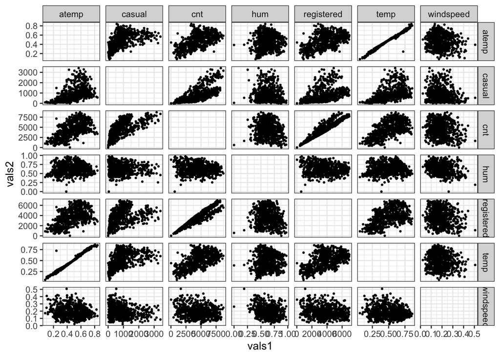

Видно, что в переменной `atemp` есть значение, которое оказалось неожиданно низким по сравнению с соответствующим значением переменной `temp`. Либо в этот день было относительно тепло, но клиентам сервиса казалось, что погода наоборот холодная, либо закралась некая ошибка при вводе данных. Удаляем этот выброс:

```r
fac_data_wo_na_and_outs <- fac_data_wo_na %>% filter(!(atemp < 0.3 & temp > 0.5))
```

Также в переменной `hum` можно увидеть 2 очень низких значения, которые выбиваются из остального набора измерений.

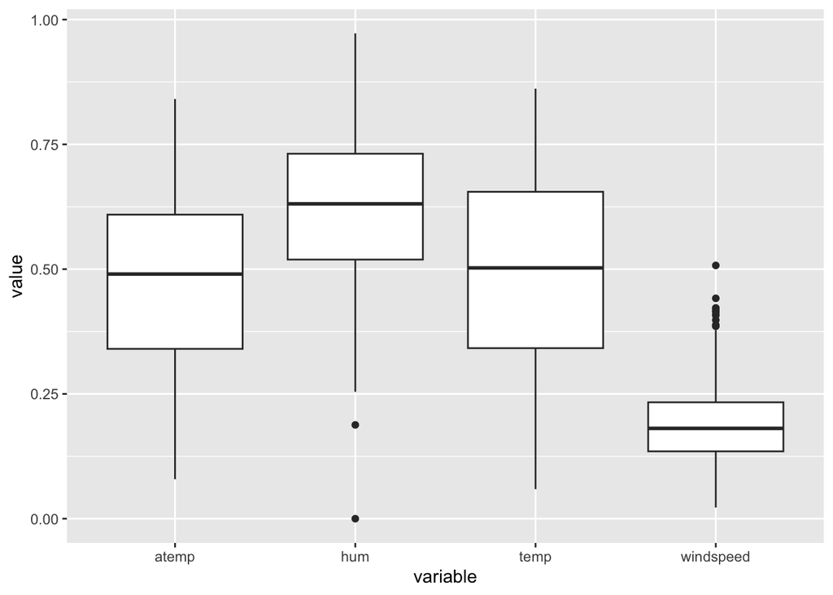

Однако если посмотреть на графики по переменным `hum` и `casual`, `registered`, `cnt`, то становится заметно, что этим низким измерениям влажности соответствует и низкое число клиентов сервиса проката. Вероятно, между этими переменными существует взаимосвязь, поэтому не стоит их пока что удалять.

Также в переменной `windspeed` также есть ряд выбросов, один из которых сильно выше остального набора измерений. Тем не менее взаимосвязь этой переменной с другими пока не была изучена и удалять эти выбросы преждевременно также не стоит.

Мы проверили данные на наличие выбросов, убрали отсутствующие значения и присвоили категориальным переменным правильный тип данных. Можно переходить к разведочному анализу данных.

```r
work_data <- fac_data_wo_na_and_outs
```

## Разведочный анализ данных

Посмотрим на результат функции summary():

```r
summary(work_data)
```

```
##     instant         dteday          season  yr           mnth     holiday
##  Min.   :  1.0   Length:721         1:176   0:359   3      : 62   0:700
##  1st Qu.:187.0   Class :character   2:182   1:362   5      : 62   1: 21
##  Median :367.0   Mode  :character   3:187           7      : 62
##  Mean   :366.8                      4:176           10     : 62
##  3rd Qu.:547.0                                      8      : 61
##  Max.   :731.0                                      12     : 61
##                                                     (Other):351
##  weekday workingday weathersit      temp             atemp
##  0:105   0:229      1:456      Min.   :0.05913   Min.   :0.07907
##  1:103   1:492      2:244      1st Qu.:0.34167   1st Qu.:0.34026
##  2:102              3: 21      Median :0.50250   Median :0.49012
##  3:102                         Mean   :0.49691   Mean   :0.47642
##  4:104                         3rd Qu.:0.65500   3rd Qu.:0.60923
##  5:102                         Max.   :0.86167   Max.   :0.84090
##  6:103
##       hum           windspeed           casual       registered
##  Min.   :0.0000   Min.   :0.02239   Min.   :   2   Min.   :  20
##  1st Qu.:0.5192   1st Qu.:0.13495   1st Qu.: 317   1st Qu.:2507
##  Median :0.6308   Median :0.18097   Median : 724   Median :3662
##  Mean   :0.6284   Mean   :0.19043   Mean   : 853   Mean   :3668
##  3rd Qu.:0.7312   3rd Qu.:0.23321   3rd Qu.:1097   3rd Qu.:4801
##  Max.   :0.9725   Max.   :0.50746   Max.   :3410   Max.   :6946
##
##       cnt
##  Min.   :  22
##  1st Qu.:3194
##  Median :4563
##  Mean   :4521
##  3rd Qu.:5986
##  Max.   :8714
##
```

### Исследование взаимодействий

Посмотрим на возможные корреляции между количественными переменными. Используем коэффициент корреляции Спирмена, так как первично не проверяем данные на нормальность распределения.

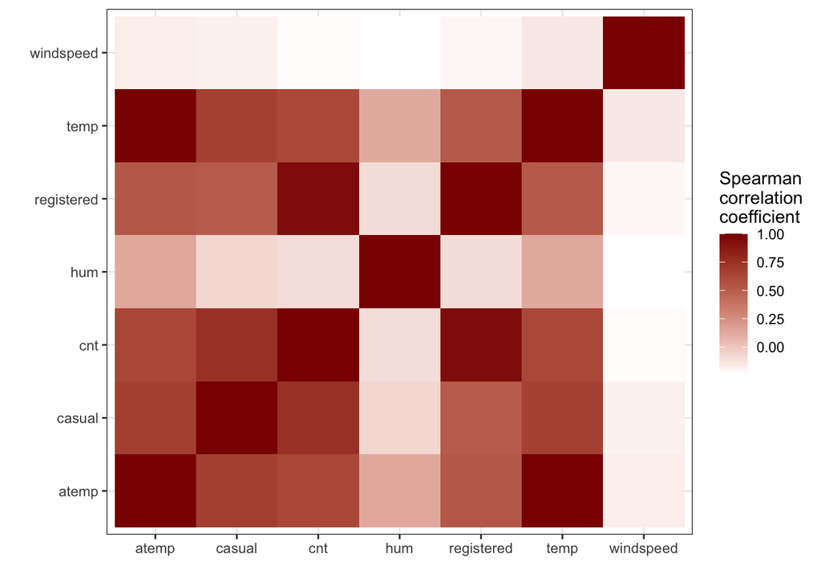

Как мы видим, для переменной `windspeed` практически не наблюдается сильной корреляции ни с одной другой количественной переменной, то же самое можно сказать и о переменной `hum`. Однако число арендованных велосипедов заметно коррелирует с температурой, как реальной, так и субъективной.

Для категориальных переменных можем, например, увидеть, что во второй год наблюдений число арендованных велосипедов было выше, чем в первый.

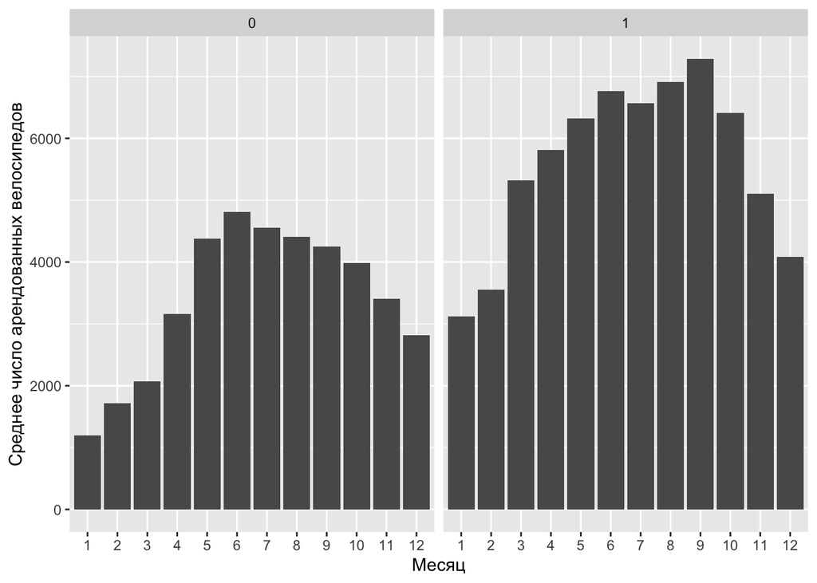

Мы подготовили данные, посмотрели на основные описательные статистики и исследовали взаимодействия между переменными. Приступаем к проверке гипотез.

## Гипотеза 1

**Летом количество пользователей сервиса проката больше чем зимой?**

Проверим гипотезу: летом количество пользователей сервисом проката велосипедов и самокатов увеличивается

H0: Количество пользователей (casual и registered) летом и зимой одинаковое

H1: Летом сервис пользуется большей популярностью, чем зимой

alpha = 0.05

```r
# Создаем новый столбец с суммой casual + registered
work_data$total_users <- work_data$casual + work_data$registered

# Выбираем данные за лето и зиму
summer <- work_data$total_users[work_data$season == 3]
winter <- work_data$total_users[work_data$season == 1]

# Проверка нормальности
shapiro.test(summer)
```

```
##
##  Shapiro-Wilk normality test
##
## data:  summer
## W = 0.96354, p-value = 8.86e-05
```

```r
shapiro.test(winter)
```

```
##
##  Shapiro-Wilk normality test
##
## data:  winter
## W = 0.94306, p-value = 1.769e-06
```

Поскольку p-value в обоих случаях очень малы (намного меньше 0.05), нулевая гипотеза отвергается. Это значит, что распределения данных summer и winter статистически значимо отличаются от нормального распределения. Поэтому при анализе данных лучше использовать непараметрические тесты или учитывать ненормальность данных.

Применим тест Манна-Уитни для проверки нашей гипотезы

```r
wilcox.test(summer, winter, alternative = "greater")
```

```
##
##  Wilcoxon rank sum test with continuity correction
##
## data:  summer and winter
## W = 30446, p-value < 2.2e-16
## alternative hypothesis: true location shift is greater than 0
```

p-value < 0.05, отвергаем нулевую гипотезу и считаем, что летом пользователей значительно больше.

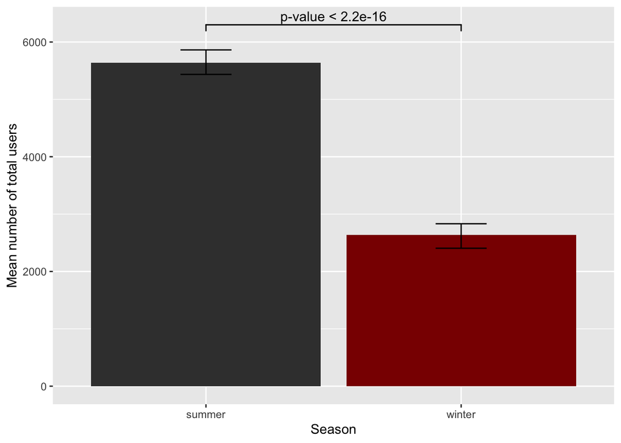

## Гипотеза 2

**Зимой сервисом проката преимущественно пользуются зарегистрированные пользователи**

Проверим гипотезу: зимой доля зарегистрированных пользователей больше чем летом

H0: Доля зарегистрированных пользователей летом и зимой одинакова

H1: Зимой сервисом пользуются в основном зарегистрированные клиенты

alpha = 0.05

```r
# Создаем столбец с долей зарегистрированных пользователей
work_data$registered_ratio <- work_data$registered / work_data$total_users

# Выбираем данные за лето и зиму
registered_ratio_summer <- work_data$registered_ratio[work_data$season == 3]
registered_ratio_winter <- work_data$registered_ratio[work_data$season == 1]

# Проводим тест Манна-Уитни с альтернативной гипотезой, что зимой доля больше
wilcox.test(registered_ratio_winter, registered_ratio_summer, alternative = "greater")
```

```
##
##  Wilcoxon rank sum test with continuity correction
##
## data:  registered_ratio_winter and registered_ratio_summer
## W = 25883, p-value < 2.2e-16
## alternative hypothesis: true location shift is greater than 0
```

В данном случае тест показал статистику около 25883 и очень маленькое значение p (около 2.2e-16), что говорит о значимом различии в долях зарегистрированных пользователей: зимой эта доля действительно значительно выше, чем летом

## Гипотеза 3

**Kоличество аренд велосипедов в нерабочие дни выше, чем в рабочие.**

Проверим гипотезу: есть ли различие в среднем числе аренд между рабочими и нерабочими днями?

H₀: среднее количество аренд велосипедов в рабочие и нерабочие дни одинаково,

H₁: средние значения количества аренд велосипедов в рабочие и нерабочие дни различаются.

alpha = 0.05

```r
# рабочие (1) и нерабочие (0) дни
table(work_data$workingday)
```

```
##
##   0   1
## 229 492
```

```r
# разделяем данные по рабочим и нерабочим дням
# cnt - общее количество арендованных велосипедов за день
cnt_working <- work_data$cnt[work_data$workingday == 1]
cnt_nonworking <- work_data$cnt[work_data$workingday == 0]

# для проверки нормального распределения данных проводим тест Шапиро-Уилка
shapiro.test(cnt_working)
```

```
##
##  Shapiro-Wilk normality test
##
## data:  cnt_working
## W = 0.97734, p-value = 6.372e-07
```

```r
shapiro.test(cnt_nonworking)
```

```
##
##  Shapiro-Wilk normality test
##
## data:  cnt_nonworking
## W = 0.97654, p-value = 0.0007457
```

В обоих случаях p < 0.05, это означает, что распределения данных ненормальные. Это подтверждается и по гистограммам, которые показывают, что данные имеют смещение и не похожи на нормальное распределение.

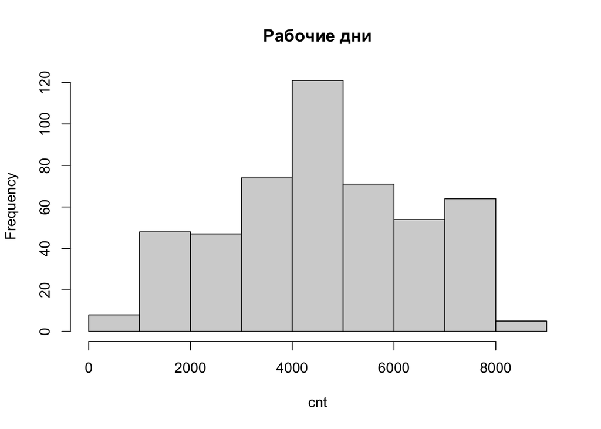

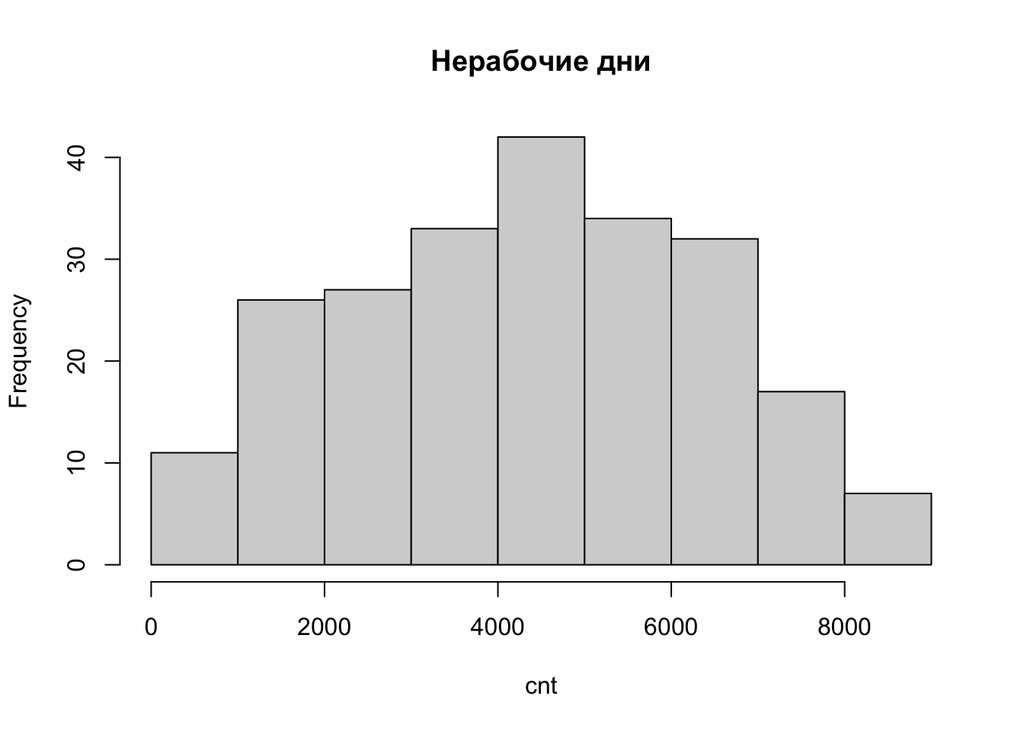

Таким образом, для проверки гипотезы используем непараметрический критерий Манна-Уитни, U-тест

```r
#применяем тест Манна-Уитни
wilcox.test(cnt_working, cnt_nonworking, alternative = "two.sided")
```

```
##
##  Wilcoxon rank sum test with continuity correction
##
## data:  cnt_working and cnt_nonworking
## W = 60614, p-value = 0.1002
## alternative hypothesis: true location shift is not equal to 0
```

В результате теста Манна-Уитни, полученное значение p-value = 0.1002 > 0.05, нулевая гипотеза не отвергается. Следовательно, статистически значимых различий в количестве аренд велосипедов между рабочими и нерабочими днями не обнаружено.

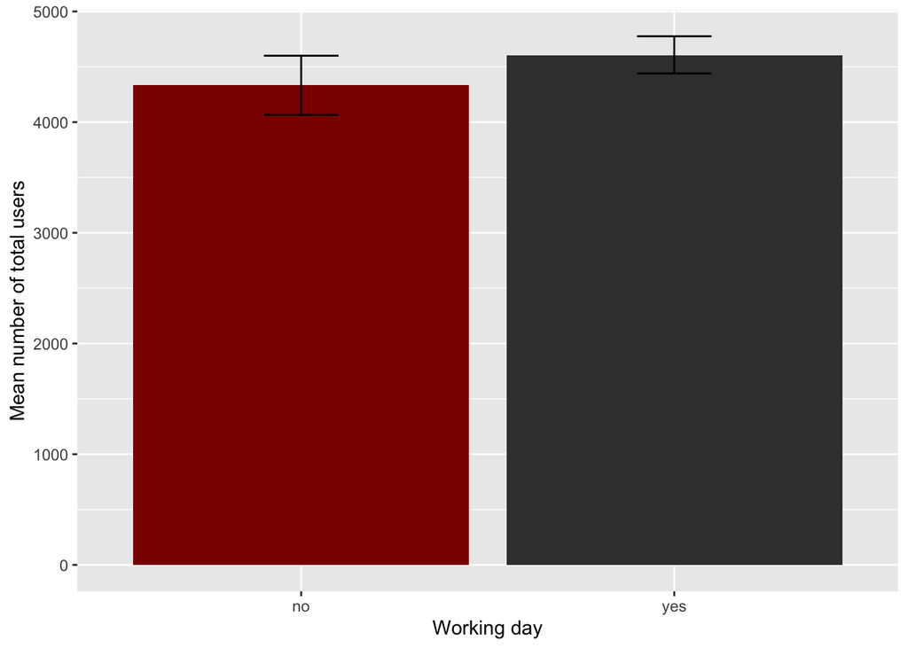

## Выводы

Нами был проведён анализ и предварительная подготовка данных сервиса проката велосипедов в Вашингтоне за 2011-2012 гг. Был загружен датасет, состоящий из 731 наблюдения за 2 года. Мы проверили его структуру и исправили некорректные типы переменных. Были удалены отсутствующие значения, выявлены и исключены явные выбросы, а категориальным переменным присвоены правильные факторы.

Разведочный анализ показал, что:

- подавляющее большинство клиентов - это зарегистрированные пользователи,
- количество арендованных велосипедов зависит от температуры,
- во второй год наблюдений количество аренд в среднем были выше, чем в первый год.

В процессе анализа данных сервиса проката велосипедов в Вашингтоне за 2011-2012 гг. нами была осуществлена проверка трех гипотез, отражающих влияние сезона и календарных факторов на использование сервиса.

**Гипотеза 1**: Летом количество пользователей сервиса проката больше чем зимой.

- Проверка нормальности по тесту Шапиро-Уилка показало, что распределения данных ненормальные, следовательно был выбран Манн-Уитни U-тест
- По результатам непараметрического теста Манна-Уитни была отвергнута нулевая гипотеза (p-value < 0.05).
- Таким образом, пользователи обращаются к сервису проката велосипедов летом статистически значимо чаще, чем зимой.

**Гипотеза 2**: Зимой сервисом проката преимущественно пользуются зарегистрированные пользователи.

- Для анализа была рассчитана доля зарегистрированных пользователей среди всех аренд.
- Непараметрический тест Манна-Уитни показал очень малое значение p-value (≈ 2.2×10^(−16)), что свидетельствует о наличии значимых различий, нулевая гипотеза отвергнута.
- Таким образом, в зимний период доля зарегистрированных клиентов действительно выше, чем летом, то есть случайные пользователи менее активны в холодное время года.

**Гипотеза 3**: Kоличество аренд велосипедов в нерабочие дни выше, чем в рабочие.

- Тесты Шапиро-Уилка на нормальность показали ненормальное распределение данных, поэтому использовался непараметрический критерий Манна-Уитни U-тест.
- Полученное значение p-value = 0.1002, что больше 0.05, следовательно нулевая гипотеза не отвергнута.
- Таким образом, статистически значимых различий в числе аренд между рабочими и нерабочими днями не выявлено. Хотя, предположительно можно ожидать более высокую активность пользователей аренды велосипедов в выходные дни, но данные за 2011-2012 гг. этого не подтверждают.

Исходя из анализа данных и проверки трех гипотез можно сделать вывод, что сезон и статус пользователя оказывают более значимое влияние на использование сервиса проката велосипедов, тогда как фактор рабочий или нерабочий день статистически значимого эффекта не продемонстрировал.